# Bias in pre-post designs – An example from the Turnbaugh et al (2006) mouse fecal transplant study

Jeffrey A. Walker

2/17/2018

# Summary

This post is motivated by a twitter link to a [recent blog post](https://honey-guide.com/2018/02/13/graphic-faecal-transplants-and-obesity/) critical of the old but influential study [An obesity-associated gut microbiome with increased capacity for energy harvest](https://scholar.google.co.uk/scholar?hl=en&as_sdt=0%2C5&q=An+obesity-associated+gut+microbiome+with+increased+capacity+for+energy+harvest.&btnG=) with [impressive citation metrics](https://www.nature.com/articles/nature05414/metrics). In the post, Matthew Dalby smartly used the available data to reconstruct the final weights of the two groups. He showed these final weights were nearly the same, which is not good evidence for a treamtment effect, given that the treatment was randomized among groups.

# The original results

Turnbaugh et al. showed that mice with feces from obese (*ob/ob*) donors had higher weight gain than mice with feces from lean (*+/+*) donors, presumably because of the differences in microbial communities between the donor types (shown elsewhere in their paper). To support the inference of a large difference in weight change, they illustrated the percent change in each treatment level in their Fig 3C, which I replicate using simulated data generated to match their summary statistics (the original data are not available). Turnbaugh et al. used a simple t-test of the percent change scores (there is also correlated error or clustering due to two donors and 4-5 recipients per donor, but I ignore this and assume independence).

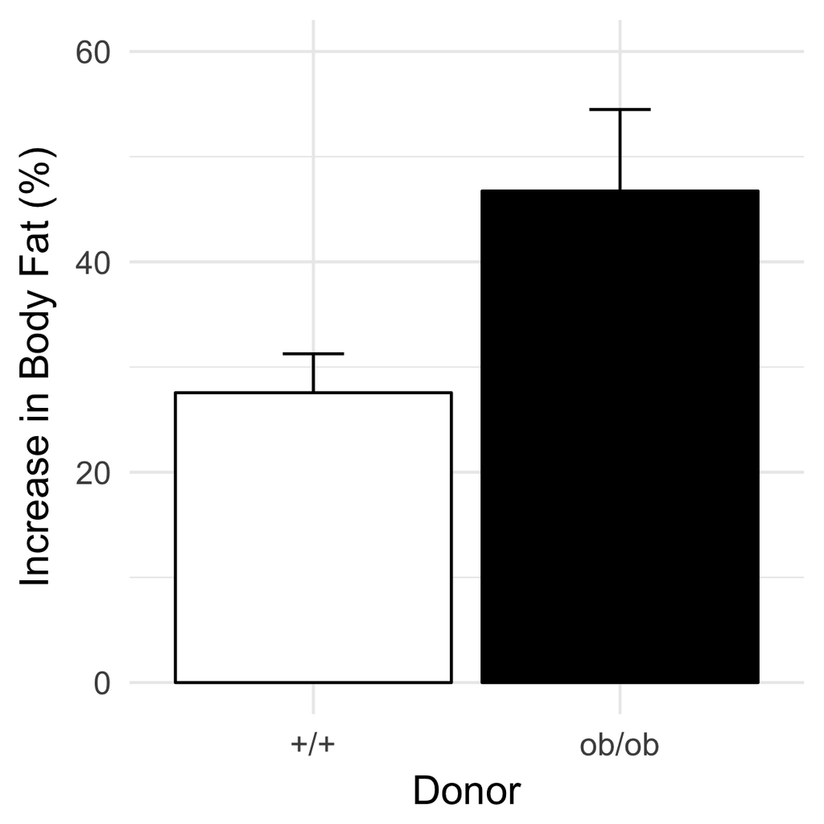

A simulated version of Fig. 3c of Turnbaugh et al. 2006

# Regression to the mean

If the first measure of a random variable is extreme, the second measure will tend to be less extreme. And, if a second measure is extreme, the first measure will tend to be less extreme. Despite random treatment assignment, the mean initial weight of the *ob/ob* group was 1.2SD less than the mean initial weight of the *+/+* group. By contrast, the mean final weight of the *ob/ob* group was 0.06SD larger than the mean final weight of the *+/+* group. This first difference is an extreme measure. The second is extremely close to the expectation. Because the mice are growing, the final weights will be higher than the initial weights and, consequently, the initial *ob/ob* measure is further from the expected final measure compared to the initial *+/+* measure. Therefore, unless the correlation between initial and final weight is 1.0, we expect there to be a larger change (from initial to final weight) in the *ob/ob* group than in the *+/+* group. This is pretty easy to simulate, which I do here with data modeled after the mouse data.

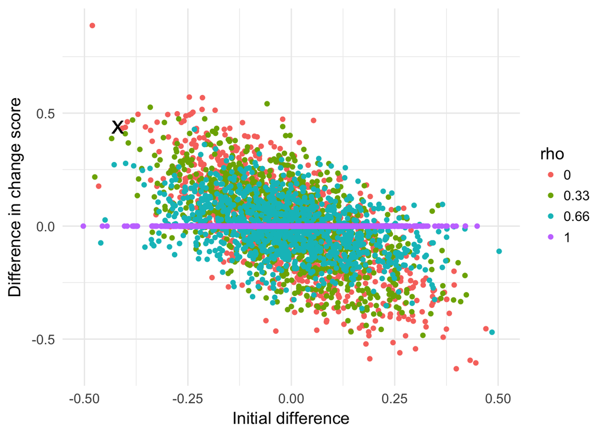

One might reasonably expect that if mice are randomized into two groups then the expected difference in change score (final - inital weight) is zero. This is not unconditionally true, that is, the expected change score is conditional on the initial difference in weights. Expected change is opposite in sign but proportional to the magnitude of the initial difference. If the initial difference ($B_{init} - A_{init}$) is unusally negative because $B_{init}$ is unusually small (or $A_{init}$ unusally big) then the difference in change score ($(B_{final} - B_{init}) - (A_{final} - A_{init}))$ will be tend to be unusually positive. The degree of the effect is a function of $\rho$ – the correlation between initial and final measures.

The dependency of the difference in change between treatments on the initial difference between treatments is more severe if change is measured as a percent, because the numerator (the change score) is expected to be larger if the denominator is smaller (initial measure). Using the simulated data from above, here is this dependency.

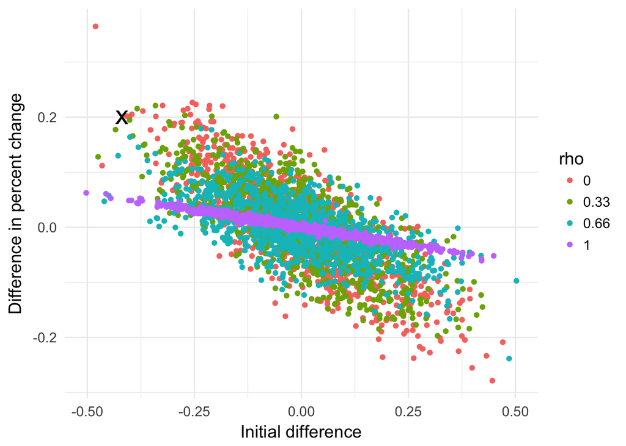

# Bias as a function of difference at baseline

There are three common measures of the treatment effect in a randomized experiment with both pre-treatment and post-treatment measures:

1. The simple difference in final measures: $\hat{\tau}_{post} = \bar Y_t - \bar Y_c$
2. The difference in change (or gain) score: $\hat{\tau}_{cs} = (\bar Y_t - \bar X_t) - (\bar Y_c - \bar X_c)$
3. The difference in percent change: $\hat{\tau}_{\%} = \bar Y'_t - \bar Y'_c$, where $Y'_i=\frac{Y_i - X_i}{X_i}$

where $X_t$ and $X_c$ are the pre-treatment (baseline) measures for treatment and control groups and $Y_t$ and $T_c$ are post-treatment measures. As in Turnbaugh et al. (2006), these difference effects are frequently tested with a simple $t$-test. It is common, however, to add the initial measure to either of the first two as a covariate in an ANCOVA model.

It is easy to show with a simple simulation that regression to the mean effects the estimate of the treatment effect $\tau$ of all three differences, except under very limited conditions, *unless the initial measure is included in the model*.

## Bias in absolute change

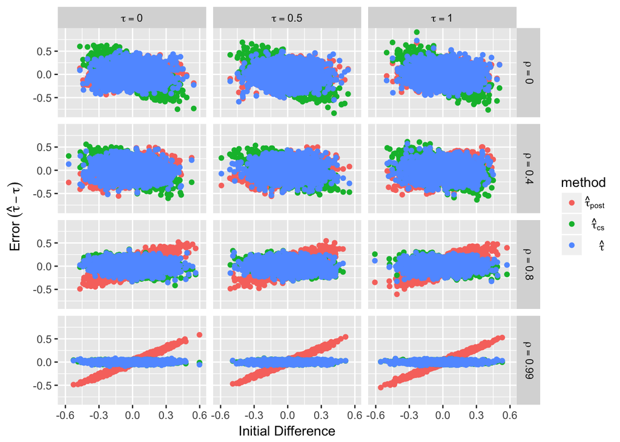

Each panel in the plot above shows the error in the estimate of the treatment effect as a function of the initial difference ($X_t - X_c$), the correlation between pre-treatment and post-treatment measures ($\rho$), and the standardized treatment effect $(\tau/\sigma)$. Three estimators are compared: the difference in final measure ($\hat{tau}_{post}$), the difference in change score ($\hat{tau}_{cs}$), and the difference in the change score adjusted for initial measure ($\hat{tau}$). The error in both $\hat{tau}_{post}$ and $\hat{tau}_{cs}$ are functions of the initial difference, except at some very specific value of $\rho$. $\hat{tau}_{post}$ is not dependent on the initial difference only if $\rho=0$ while $\hat{tau}_{cs}$ is not dependent on the initial difference only if $\rho=1$. If we want our statistical inference to be independent of the initial difference, a simple $t$-test of post-treatment differences would have to assume that final measures are not at all predictable from initial measures while a simple $t$-test of the change scores would have to assume that final measures are entirely predictable from initial measures.

## Bias in percent change

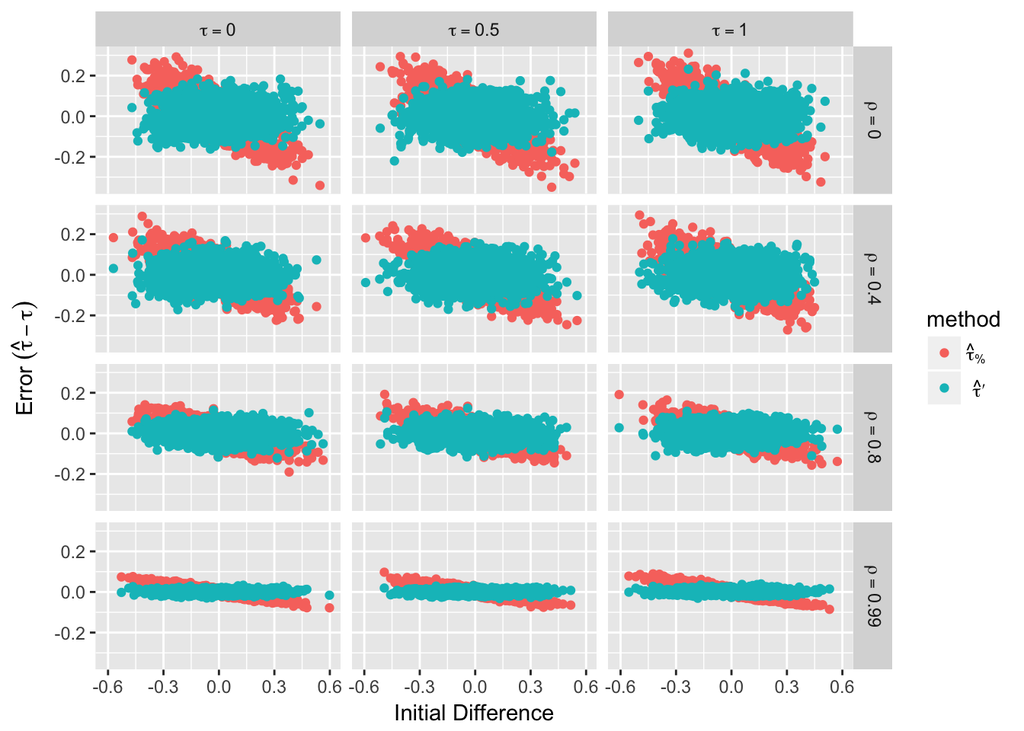

The plot above shows the error in the estimate of the treatment effect using the percent change $(\hat{\tau}_{\%})$, as in Turnbaugh et al. (2006), and the percent change with the initial measure as a covariate in a linear model $(\hat{\tau}')$. $(\hat{\tau}_{\%})$ is a function of the initial difference and, unlike the simple post-treatment difference or the change score, there is no $\rho$ for which this dependency goes to zero.

# Conditional bias in pre-post designs

The conclusions derived from the plots of the data from the simulation experiment are easy to derive using simple algebra.

## A conditionally unbiased estimator of the treatment effect

**The coefficient of the treatment variable in an ANCOVA-like linear model with the initial measure as a covariate is an unbiased estimator of the treatment effect in randomized designs**

In a randomized experiment with a pre-treatment measure $X$ and a post-treatment measure $Y$, an unbiased estimate of the treatment effect $\tau$ is found by modeling the post-treatment measure using the ANCOVA-like linear model
$$Y = \alpha + \beta X + \tau T$$
where $T$ is a dummy variable indicating treatment assignment with $T=0$ assigned to the control group and $T=1$ to the treated group. If the pre-treatment and post-treatment variance is the same, then $\beta$ is the correlation between initial and final measures.

The equivalent estimate of $\tau$ can be computed by modeling the change score $Y - X$
$$Y - X = \alpha + \beta^* X + \tau T$$
but the coefficient of $X$ is now $\beta - 1$.

## Conditionally biased estimators

**The three difference measures are conditionally biased**

The three difference measures given above have unconditional expectations of zero in a randomized experiment with no true effect ($\tau = 0$). But, and this is an important but, all three have non-zero expectations conditioned on the initial difference ($\bar X_t - \bar X_c$). Each of the three difference statistics makes a very specific assumption about the value of $\beta$, which is a function of the pre-post correlation ($\rho$). As the difference between $\beta$ and its assumed value increases, the rate of magnitude (Type M) and sign (Type S) error of these effects increase. Or, in a hypothesis testing framework, there will be increased Type I error as $\beta$ moves away from its assumed value, *despite* an uncoditional Type I error equal to 0.05 (or whatever value set by the investigator).

To see how these difference effects are related to $\tau$, and to show the added assumption of each difference measure, break up the linear model above by treatment level:

$$\bar Y_c = \alpha + \beta \bar X_c$$
for the control group and

$$\bar Y_t = \alpha + \beta \bar X_t + \tau$$
for the treatment group. We can use these to show how each difference effect is dependent on $\beta$.

1. the simple difference in final measures: $\hat{\tau}_{post} = \bar Y_t - \bar Y_c$

Note that

$$\hat{\tau}_{post} = \bar Y_t - \bar Y_c = \tau + \beta(\bar X_t - \bar X_c)$$

and, consequently, the simple difference in final measures as an estimate of $\tau$, is biased by $\beta(X_t - X_c)$. If $\beta$ does not equal 0, the simple difference is dependent on the difference in initial measures.

2. the change score: $\hat{\tau}_{cs} = (\bar Y_t - \bar X_t) - (\bar Y_c - \bar X_c)$

To see how this is related to $\tau$, re-arrange the above equation for $\hat{\tau}_{post}$ to solve for $\tau$

$$\tau = (\bar Y_t - \bar Y_c) - \beta(\bar X_t - \bar X_c)$$
and re-arrange this to
$$\tau = (\bar Y_t - \beta \bar X_t) - (\bar Y_c - \beta \bar X_c)$$
This equation is that for the change score if $\beta=1$. If $\beta \ne 1$, the change score is dependent on the difference in initial measures.

3. the difference in percent change: $\hat{\tau}_{\%} = \bar Y'_t - \bar Y'_c$, where $Y'_i=\frac{Y_i - X_i}{X_i}$

For the percent change, the relationship is similar to that for the simple difference, only the linear model fits the percent change instead of simple difference.

$$\bar Y'_c = \alpha' + \beta' \bar X_c$$
and

$$\bar Y'_t = \alpha' + \beta' \bar X_t + \tau'$$
where $\tau'$ is the unbiased estimate of the effect as a percent change. As above,

$$\hat{\tau}_{\%} = \bar Y'_t - \bar Y'_c = \tau' + \beta'(\bar X_t - \bar X_c)$$
and, like the simple difference, the percent difference is dependent on the initial difference unless $\beta'=0$